# Tutorial(Bike)-SHAP

This tutorial is created by Juhee Bae to instruct "Explainable AI". Refer to the lecture and the code provided on Canvas. Do not share with external venues. Refer to this tutorial to solve the assignment.

## Contents

- Setup
- Data cleaning
  - Categorical variables
  - Numerical variables
- Grid search and modeling
- Train
- Predict
- Explain model with SHAP
  - Global explanation
    - SHAP Summary Plot
    - SHAP Dependence Plot
    - SHAP Interaction Value Plot
  - Local explanation

```python
import pandas as pd
import numpy as np
np.random.seed(0)
import matplotlib.pyplot as plt
import seaborn as sb

from sklearn.preprocessing import OneHotEncoder, StandardScaler
from sklearn.model_selection import train_test_split
from sklearn.metrics import mean_squared_error, mean_absolute_error
from sklearn import preprocessing
from sklearn.model_selection import train_test_split, GridSearchCV
import xgboost as xgb

import shap
import time
import warnings
```

# Setup and overview

[For detailed information](https://archive.ics.uci.edu/ml/datasets/bike+sharing+dataset)

```python
df = pd.read_csv('../data/day-bikesharing.csv',parse_dates=['dteday'],index_col=1) # Load the data
```

```python
df.shape
```

```
(731, 15)
```

```python
def add_features(df):
    df['year'] = df.index.year # yr exists already
    df['month'] = df.index.month
    df['day'] = df.index.day
    df['dayofweek'] = df.index.dayofweek
```

2011.Jan.1 is a Saturday.

Note: 'dayofweek' 5 means a Saturday.

```python
add_features(df)
df.head(3)
```

| dteday | instant | season | yr | mnth | holiday | weekday | workingday | weathersit | temp | atemp | hum | windspeed | casual | registered | cnt | year | month | day | dayofweek |
| --- | --- | --- | --- | --- | --- | --- | --- | --- | --- | --- | --- | --- | --- | --- | --- | --- | --- | --- | --- |
| 2011-01-01 | 1 | 1 | 0 | 1 | 0 | 6 | 0 | 2 | 0.344167 | 0.363625 | 0.805833 | 0.160446 | 331 | 654 | 985 | 2011 | 1 | 1 | 5 |
| 2011-01-02 | 2 | 1 | 0 | 1 | 0 | 0 | 0 | 2 | 0.363478 | 0.353739 | 0.696087 | 0.248539 | 131 | 670 | 801 | 2011 | 1 | 2 | 6 |
| 2011-01-03 | 3 | 1 | 0 | 1 | 0 | 1 | 1 | 1 | 0.196364 | 0.189405 | 0.437273 | 0.248309 | 120 | 1229 | 1349 | 2011 | 1 | 3 | 0 |

## Notice: We select meaningful variables for a better understanding of the SHAP results.

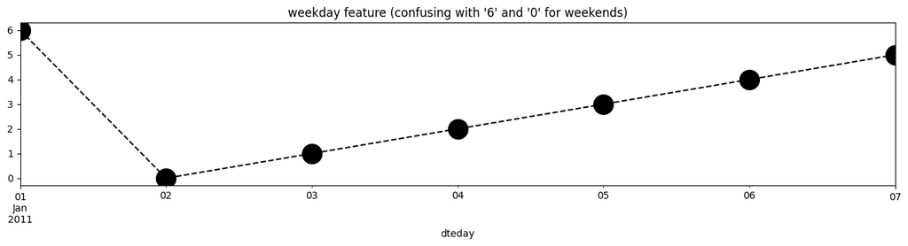

```python
# Let's use 'dayofweek' instead of 'weekday'.
plt.figure(figsize=(16,3))
df['weekday'][:7].plot(linestyle='--', marker='o', color='k', ms=20,
                       title='weekday feature (confusing with \'6\' and \'0\' for weekends)')
plt.show()
```

## We will use 'dayofweek' variable when describing each day of a week. Weekends of Saturday and Sunday are 5 and 6. The other weekdays are 0 to 4.

- When analyzing with SHAP, we consider higher numbers of 'dayofweek' feature to show the weekends.

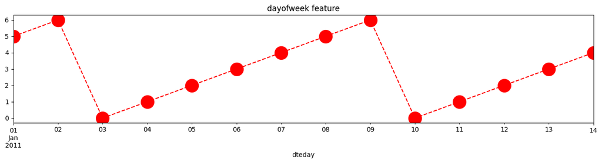

```python
plt.figure(figsize=(16,3))
df['dayofweek'][:14].plot(linestyle='--', marker='o', color='r', ms=20,
                       title='dayofweek feature')
plt.show()
```

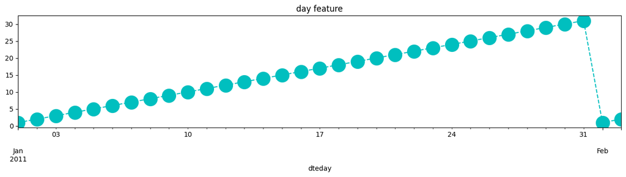

```python
# Day feature shows whether it is a start of the month or the end of the month (1 to 30 or 31).
plt.figure(figsize=(16,3))
df['day'][:33].plot(linestyle='--', marker='o', color='c', ms=20, title='day feature')
plt.show()
```

## Workingday feature is a boolean.

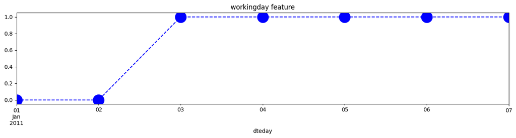

```python
plt.figure(figsize=(16,3))
df['workingday'][:7].plot(linestyle='--', marker='o', color='b', ms=20, title='workingday feature')
plt.show()
```

## Note that season 1 indicates winter. Do you agree?

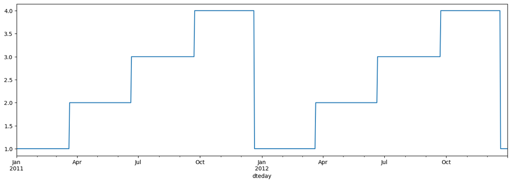

```python
plt.figure(figsize=(16,5))
df['season'].plot()
plt.show()
```

```python
df.season.value_counts()
```

```
3    188
2    184
1    181
4    178
Name: season, dtype: int64
```

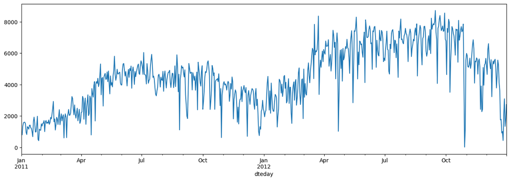

```python
plt.figure(figsize=(16,5))
df['cnt'].plot()
plt.show()
```

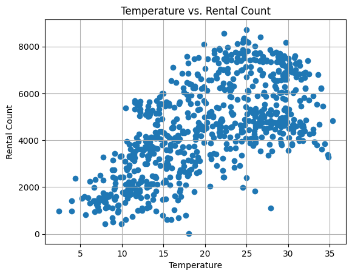

```python
plt.scatter(x=df.temp*41,y=df["cnt"]) # denormalize temperature by multiplying 41
plt.grid(True)
plt.xlabel('Temperature')
plt.ylabel('Rental Count')
plt.title('Temperature vs. Rental Count')
plt.show()
```

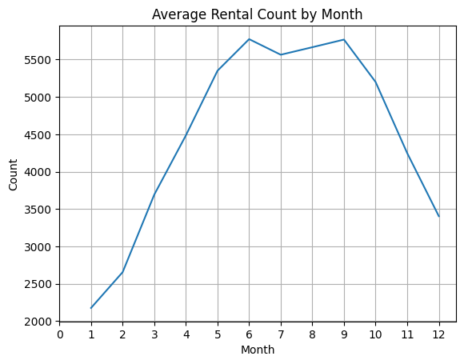

```python
# from January to April, the demand is relatively low due to Winter
#(there are not a lot of people that's brave enough to bike on icy road, are there?).
# And the peak demand happends around Summer time (from May to October) and drop again.
group_month = df.groupby(['month'])
average_by_month = group_month['cnt'].mean()

plt.plot(average_by_month.index,average_by_month)
plt.xlabel('Month')
plt.ylabel('Count')
plt.xticks(np.arange(13))
plt.grid(True)
plt.title('Average Rental Count by Month')
```

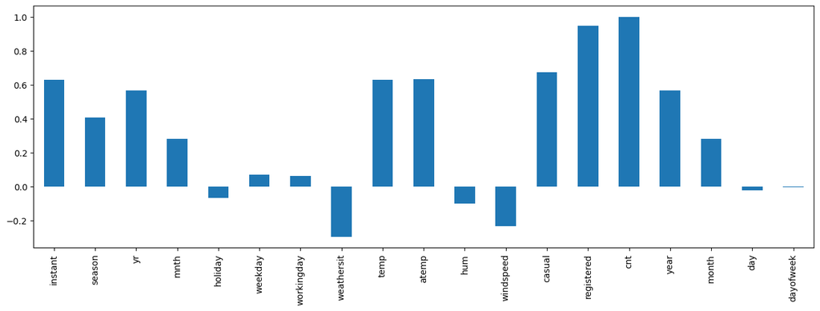

```python
#correlation of total cnt with other variables
plt.figure(figsize=(16,5))
df.corr()['cnt'].plot(kind='bar')
plt.show()
```

```python
#This is the normalized version.
# temp: The values are divided to 41 (max)
# atemp: The values are divided to 50 (max)
# hum: The values are divided to 100 (max)
# windspeed: The values are divided to 67 (max)
df.describe().T
```

|  | count | mean | std | min | 25% | 50% | 75% | max |
| --- | --- | --- | --- | --- | --- | --- | --- | --- |
| instant | 731.0 | 366.000000 | 211.165812 | 1.000000 | 183.500000 | 366.000000 | 548.500000 | 731.000000 |
| season | 731.0 | 2.496580 | 1.110807 | 1.000000 | 2.000000 | 3.000000 | 3.000000 | 4.000000 |
| yr | 731.0 | 0.500684 | 0.500342 | 0.000000 | 0.000000 | 1.000000 | 1.000000 | 1.000000 |
| mnth | 731.0 | 6.519836 | 3.451913 | 1.000000 | 4.000000 | 7.000000 | 10.000000 | 12.000000 |
| holiday | 731.0 | 0.028728 | 0.167155 | 0.000000 | 0.000000 | 0.000000 | 0.000000 | 1.000000 |
| weekday | 731.0 | 2.997264 | 2.004787 | 0.000000 | 1.000000 | 3.000000 | 5.000000 | 6.000000 |
| workingday | 731.0 | 0.683995 | 0.465233 | 0.000000 | 0.000000 | 1.000000 | 1.000000 | 1.000000 |
| weathersit | 731.0 | 1.395349 | 0.544894 | 1.000000 | 1.000000 | 1.000000 | 2.000000 | 3.000000 |
| temp | 731.0 | 0.495385 | 0.183051 | 0.059130 | 0.337083 | 0.498333 | 0.655417 | 0.861667 |
| atemp | 731.0 | 0.474354 | 0.162961 | 0.079070 | 0.337842 | 0.486733 | 0.608602 | 0.840896 |
| hum | 731.0 | 0.627894 | 0.142429 | 0.000000 | 0.520000 | 0.626667 | 0.730209 | 0.972500 |
| windspeed | 731.0 | 0.190486 | 0.077498 | 0.022392 | 0.134950 | 0.180975 | 0.233214 | 0.507463 |
| casual | 731.0 | 848.176471 | 686.622488 | 2.000000 | 315.500000 | 713.000000 | 1096.000000 | 3410.000000 |
| registered | 731.0 | 3656.172367 | 1560.256377 | 20.000000 | 2497.000000 | 3662.000000 | 4776.500000 | 6946.000000 |
| cnt | 731.0 | 4504.348837 | 1937.211452 | 22.000000 | 3152.000000 | 4548.000000 | 5956.000000 | 8714.000000 |
| year | 731.0 | 2011.500684 | 0.500342 | 2011.000000 | 2011.000000 | 2012.000000 | 2012.000000 | 2012.000000 |
| month | 731.0 | 6.519836 | 3.451913 | 1.000000 | 4.000000 | 7.000000 | 10.000000 | 12.000000 |
| day | 731.0 | 15.738714 | 8.809949 | 1.000000 | 8.000000 | 16.000000 | 23.000000 | 31.000000 |
| dayofweek | 731.0 | 3.002736 | 2.004787 | 0.000000 | 1.000000 | 3.000000 | 5.000000 | 6.000000 |

```python
df.dtypes
```

```
instant         int64
season          int64
yr              int64
mnth            int64
holiday         int64
weekday         int64
workingday      int64
weathersit      int64
temp          float64
atemp         float64
hum           float64
windspeed     float64
casual          int64
registered      int64
cnt             int64
year            int64
month           int64
day             int64
dayofweek       int64
dtype: object
```

# Categorical variables

Perform one hot encoding on categorical variables. Machine learning algorithms assume (and require) the data to be numeric, so the categorical data must be pre-processed as a numerical data. Categorical variables turn into binary features that are 'one hot' encoded, so if a feature is represented by that column, it receives a 1, otherwise a 0.

- The 'season' feature has 1: winter, 2: spring, 3: summer, 4: fall.
- The 'holiday' and 'workingday' features are boolean: 1 when it is a holiday. 1 when it is a working day.

```python
# Define the categorical variables
cat_var = ['season', 'holiday', 'workingday', 'weathersit', 'year']
```

```python
# OneHotEncoder
ohe = OneHotEncoder(categories = 'auto')
```

```python
# Fit the categorical variables to the encoder
encodeddf = ohe.fit_transform(df[cat_var])
```

```python
# Create a DataFrame with the encoded value information
cat_df = pd.DataFrame(data = encodeddf.toarray(), columns = ohe.get_feature_names(cat_var))
cat_df
```

```
Function get_feature_names is deprecated; get_feature_names is deprecated in 1.0 and will be removed in 1.2. Please use get_feature_names_out instead.
```

|  | season_1 | season_2 | season_3 | season_4 | holiday_0 | holiday_1 | workingday_0 | workingday_1 | weathersit_1 | weathersit_2 | weathersit_3 | year_2011 | year_2012 |
| --- | --- | --- | --- | --- | --- | --- | --- | --- | --- | --- | --- | --- | --- |
| 0 | 1.0 | 0.0 | 0.0 | 0.0 | 1.0 | 0.0 | 1.0 | 0.0 | 0.0 | 1.0 | 0.0 | 1.0 | 0.0 |
| 1 | 1.0 | 0.0 | 0.0 | 0.0 | 1.0 | 0.0 | 1.0 | 0.0 | 0.0 | 1.0 | 0.0 | 1.0 | 0.0 |
| 2 | 1.0 | 0.0 | 0.0 | 0.0 | 1.0 | 0.0 | 0.0 | 1.0 | 1.0 | 0.0 | 0.0 | 1.0 | 0.0 |
| 3 | 1.0 | 0.0 | 0.0 | 0.0 | 1.0 | 0.0 | 0.0 | 1.0 | 1.0 | 0.0 | 0.0 | 1.0 | 0.0 |
| 4 | 1.0 | 0.0 | 0.0 | 0.0 | 1.0 | 0.0 | 0.0 | 1.0 | 1.0 | 0.0 | 0.0 | 1.0 | 0.0 |
| ... | ... | ... | ... | ... | ... | ... | ... | ... | ... | ... | ... | ... | ... |
| 726 | 1.0 | 0.0 | 0.0 | 0.0 | 1.0 | 0.0 | 0.0 | 1.0 | 0.0 | 1.0 | 0.0 | 0.0 | 1.0 |
| 727 | 1.0 | 0.0 | 0.0 | 0.0 | 1.0 | 0.0 | 0.0 | 1.0 | 0.0 | 1.0 | 0.0 | 0.0 | 1.0 |
| 728 | 1.0 | 0.0 | 0.0 | 0.0 | 1.0 | 0.0 | 1.0 | 0.0 | 0.0 | 1.0 | 0.0 | 0.0 | 1.0 |
| 729 | 1.0 | 0.0 | 0.0 | 0.0 | 1.0 | 0.0 | 1.0 | 0.0 | 1.0 | 0.0 | 0.0 | 0.0 | 1.0 |
| 730 | 1.0 | 0.0 | 0.0 | 0.0 | 1.0 | 0.0 | 0.0 | 1.0 | 0.0 | 1.0 | 0.0 | 0.0 | 1.0 |

731 rows × 13 columns

```python
# rename the column names from 1,2,3,4 to spring, summer, fall, winter
cat_df.rename(columns={'season_1': 'winter', 'season_2': 'spring', 'season_3': 'summer', 'season_4': 'fall'}, inplace=True)
cat_df.rename(columns={'weathersit_1': 'clear', 'weathersit_2': 'cloudy', 'weathersit_3': 'lightsnow.rain'}, inplace=True)
cat_df
```

|  | winter | spring | summer | fall | holiday_0 | holiday_1 | workingday_0 | workingday_1 | clear | cloudy | lightsnow.rain | year_2011 | year_2012 |
| --- | --- | --- | --- | --- | --- | --- | --- | --- | --- | --- | --- | --- | --- |
| 0 | 1.0 | 0.0 | 0.0 | 0.0 | 1.0 | 0.0 | 1.0 | 0.0 | 0.0 | 1.0 | 0.0 | 1.0 | 0.0 |
| 1 | 1.0 | 0.0 | 0.0 | 0.0 | 1.0 | 0.0 | 1.0 | 0.0 | 0.0 | 1.0 | 0.0 | 1.0 | 0.0 |
| 2 | 1.0 | 0.0 | 0.0 | 0.0 | 1.0 | 0.0 | 0.0 | 1.0 | 1.0 | 0.0 | 0.0 | 1.0 | 0.0 |
| 3 | 1.0 | 0.0 | 0.0 | 0.0 | 1.0 | 0.0 | 0.0 | 1.0 | 1.0 | 0.0 | 0.0 | 1.0 | 0.0 |
| 4 | 1.0 | 0.0 | 0.0 | 0.0 | 1.0 | 0.0 | 0.0 | 1.0 | 1.0 | 0.0 | 0.0 | 1.0 | 0.0 |
| ... | ... | ... | ... | ... | ... | ... | ... | ... | ... | ... | ... | ... | ... |
| 726 | 1.0 | 0.0 | 0.0 | 0.0 | 1.0 | 0.0 | 0.0 | 1.0 | 0.0 | 1.0 | 0.0 | 0.0 | 1.0 |
| 727 | 1.0 | 0.0 | 0.0 | 0.0 | 1.0 | 0.0 | 0.0 | 1.0 | 0.0 | 1.0 | 0.0 | 0.0 | 1.0 |
| 728 | 1.0 | 0.0 | 0.0 | 0.0 | 1.0 | 0.0 | 1.0 | 0.0 | 0.0 | 1.0 | 0.0 | 0.0 | 1.0 |
| 729 | 1.0 | 0.0 | 0.0 | 0.0 | 1.0 | 0.0 | 1.0 | 0.0 | 1.0 | 0.0 | 0.0 | 0.0 | 1.0 |
| 730 | 1.0 | 0.0 | 0.0 | 0.0 | 1.0 | 0.0 | 0.0 | 1.0 | 0.0 | 1.0 | 0.0 | 0.0 | 1.0 |

731 rows × 13 columns

# Numerical variables

Machine learning is sensitive to the relative scales of numerical variables. The range of all variables need to be normalized so that each feature contributes approximately proportionately to the calculation.

```python
# Define the numerical variables
num_var = ['temp', 'atemp', 'hum', 'windspeed', 'month', 'day', 'dayofweek']
```

Create standardized, normalized

```python
# StandardScaler object
scaler = StandardScaler()
```

```python
# Fit the data to the scaler
numscaled = scaler.fit_transform(df[num_var])
```

Keep the original for later view

```python
# for inverse transformation
inversed = scaler.inverse_transform(numscaled)
print(inversed)
```

```
[[ 0.344167  0.363625  0.805833 ...  1.        1.        5.      ]
 [ 0.363478  0.353739  0.696087 ...  1.        2.        6.      ]
 [ 0.196364  0.189405  0.437273 ...  1.        3.        0.      ]
 ...
 [ 0.253333  0.2424    0.752917 ... 12.       29.        5.      ]
 [ 0.255833  0.2317    0.483333 ... 12.       30.        6.      ]
 [ 0.215833  0.223487  0.5775   ... 12.       31.        0.      ]]
```

```python
# Create DataFrame with original data
inversed_df = pd.DataFrame(data = inversed, columns = num_var)
inversed_df

# Calculate based on UCI info to retrieve the actual temperature and weather information
#temp : Normalized temperature in Celsius. The values are divided to 41 (max)
#atemp: Normalized feeling temperature in Celsius. The values are divided to 50 (max)
#hum: Normalized humidity. The values are divided to 100 (max)
#windspeed: Normalized wind speed. The values are divided to 67 (max)
inversed_origin = pd.concat([inversed_df.iloc[:,0] * 41, #temperature
           inversed_df.iloc[:,1] * 50,                   #feeling temperature
           inversed_df.iloc[:,2] * 100,                  #humidity
           inversed_df.iloc[:,3] * 67],                  #wind speed
          axis=1)
inversed_origin
```

|  | temp | atemp | hum | windspeed |
| --- | --- | --- | --- | --- |
| 0 | 14.110847 | 18.18125 | 80.5833 | 10.749882 |
| 1 | 14.902598 | 17.68695 | 69.6087 | 16.652113 |
| 2 | 8.050924 | 9.47025 | 43.7273 | 16.636703 |
| 3 | 8.200000 | 10.60610 | 59.0435 | 10.739832 |
| 4 | 9.305237 | 11.46350 | 43.6957 | 12.522300 |
| ... | ... | ... | ... | ... |
| 726 | 10.420847 | 11.33210 | 65.2917 | 23.458911 |
| 727 | 10.386653 | 12.75230 | 59.0000 | 10.416557 |
| 728 | 10.386653 | 12.12000 | 75.2917 | 8.333661 |
| 729 | 10.489153 | 11.58500 | 48.3333 | 23.500518 |
| 730 | 8.849153 | 11.17435 | 57.7500 | 10.374682 |

731 rows × 4 columns

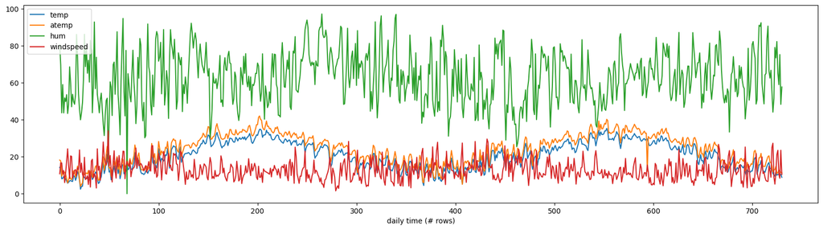

```python
# timeseries of temp, atemp, humidity, windspeed
ax = inversed_origin.set_index(inversed_origin.index).plot(figsize=(20,5))
ax.set_xlabel('daily time (# rows)')
```

```python
X_original = pd.concat([cat_df, inversed_origin, inversed_df[['month', 'day', 'dayofweek']]], axis=1)
X_original # Use this for SHAP plot view
```

|  | winter | spring | summer | fall | holiday_0 | holiday_1 | workingday_0 | workingday_1 | clear | cloudy | lightsnow.rain | year_2011 | year_2012 | temp | atemp | hum | windspeed | month | day | dayofweek |
| --- | --- | --- | --- | --- | --- | --- | --- | --- | --- | --- | --- | --- | --- | --- | --- | --- | --- | --- | --- | --- |
| 0 | 1.0 | 0.0 | 0.0 | 0.0 | 1.0 | 0.0 | 1.0 | 0.0 | 0.0 | 1.0 | 0.0 | 1.0 | 0.0 | 14.110847 | 18.18125 | 80.5833 | 10.749882 | 1.0 | 1.0 | 5.0 |
| 1 | 1.0 | 0.0 | 0.0 | 0.0 | 1.0 | 0.0 | 1.0 | 0.0 | 0.0 | 1.0 | 0.0 | 1.0 | 0.0 | 14.902598 | 17.68695 | 69.6087 | 16.652113 | 1.0 | 2.0 | 6.0 |
| 2 | 1.0 | 0.0 | 0.0 | 0.0 | 1.0 | 0.0 | 0.0 | 1.0 | 1.0 | 0.0 | 0.0 | 1.0 | 0.0 | 8.050924 | 9.47025 | 43.7273 | 16.636703 | 1.0 | 3.0 | 0.0 |
| 3 | 1.0 | 0.0 | 0.0 | 0.0 | 1.0 | 0.0 | 0.0 | 1.0 | 1.0 | 0.0 | 0.0 | 1.0 | 0.0 | 8.200000 | 10.60610 | 59.0435 | 10.739832 | 1.0 | 4.0 | 1.0 |
| 4 | 1.0 | 0.0 | 0.0 | 0.0 | 1.0 | 0.0 | 0.0 | 1.0 | 1.0 | 0.0 | 0.0 | 1.0 | 0.0 | 9.305237 | 11.46350 | 43.6957 | 12.522300 | 1.0 | 5.0 | 2.0 |
| ... | ... | ... | ... | ... | ... | ... | ... | ... | ... | ... | ... | ... | ... | ... | ... | ... | ... | ... | ... | ... |
| 726 | 1.0 | 0.0 | 0.0 | 0.0 | 1.0 | 0.0 | 0.0 | 1.0 | 0.0 | 1.0 | 0.0 | 0.0 | 1.0 | 10.420847 | 11.33210 | 65.2917 | 23.458911 | 12.0 | 27.0 | 3.0 |
| 727 | 1.0 | 0.0 | 0.0 | 0.0 | 1.0 | 0.0 | 0.0 | 1.0 | 0.0 | 1.0 | 0.0 | 0.0 | 1.0 | 10.386653 | 12.75230 | 59.0000 | 10.416557 | 12.0 | 28.0 | 4.0 |
| 728 | 1.0 | 0.0 | 0.0 | 0.0 | 1.0 | 0.0 | 1.0 | 0.0 | 0.0 | 1.0 | 0.0 | 0.0 | 1.0 | 10.386653 | 12.12000 | 75.2917 | 8.333661 | 12.0 | 29.0 | 5.0 |
| 729 | 1.0 | 0.0 | 0.0 | 0.0 | 1.0 | 0.0 | 1.0 | 0.0 | 1.0 | 0.0 | 0.0 | 0.0 | 1.0 | 10.489153 | 11.58500 | 48.3333 | 23.500518 | 12.0 | 30.0 | 6.0 |
| 730 | 1.0 | 0.0 | 0.0 | 0.0 | 1.0 | 0.0 | 0.0 | 1.0 | 0.0 | 1.0 | 0.0 | 0.0 | 1.0 | 8.849153 | 11.17435 | 57.7500 | 10.374682 | 12.0 | 31.0 | 0.0 |

731 rows × 20 columns

```python
# Create DataFrame with numerically scaled data
num_df = pd.DataFrame(data = numscaled, columns = num_var)
num_df
```

|  | temp | atemp | hum | windspeed | month | day | dayofweek |
| --- | --- | --- | --- | --- | --- | --- | --- |
| 0 | -0.826662 | -0.679946 | 1.250171 | -0.387892 | -1.600161 | -1.674108 | 0.996930 |
| 1 | -0.721095 | -0.740652 | 0.479113 | 0.749602 | -1.600161 | -1.560522 | 1.496077 |
| 2 | -1.634657 | -1.749767 | -1.339274 | 0.746632 | -1.600161 | -1.446936 | -1.498809 |
| 3 | -1.614780 | -1.610270 | -0.263182 | -0.389829 | -1.600161 | -1.333351 | -0.999661 |
| 4 | -1.467414 | -1.504971 | -1.341494 | -0.046307 | -1.600161 | -1.219765 | -0.500513 |
| ... | ... | ... | ... | ... | ... | ... | ... |
| 726 | -1.318665 | -1.521108 | 0.175807 | 2.061426 | 1.588660 | 1.279122 | -0.001366 |
| 727 | -1.323224 | -1.346690 | -0.266238 | -0.452131 | 1.588660 | 1.392707 | 0.497782 |
| 728 | -1.323224 | -1.424344 | 0.878392 | -0.853552 | 1.588660 | 1.506293 | 0.996930 |
| 729 | -1.309558 | -1.490049 | -1.015664 | 2.069444 | 1.588660 | 1.619879 | 1.496077 |
| 730 | -1.528225 | -1.540482 | -0.354061 | -0.460201 | 1.588660 | 1.733465 | -1.498809 |

731 rows × 7 columns

Define X (input): Concatenate one hot encoded categorical + normalized numerical data

```python
Xdf = pd.concat([cat_df, num_df], axis = 1)
print(Xdf.shape)
Xdf.head(5)
```

```
(731, 20)
```

|  | winter | spring | summer | fall | holiday_0 | holiday_1 | workingday_0 | workingday_1 | clear | cloudy | lightsnow.rain | year_2011 | year_2012 | temp | atemp | hum | windspeed | month | day | dayofweek |
| --- | --- | --- | --- | --- | --- | --- | --- | --- | --- | --- | --- | --- | --- | --- | --- | --- | --- | --- | --- | --- |
| 0 | 1.0 | 0.0 | 0.0 | 0.0 | 1.0 | 0.0 | 1.0 | 0.0 | 0.0 | 1.0 | 0.0 | 1.0 | 0.0 | -0.826662 | -0.679946 | 1.250171 | -0.387892 | -1.600161 | -1.674108 | 0.996930 |
| 1 | 1.0 | 0.0 | 0.0 | 0.0 | 1.0 | 0.0 | 1.0 | 0.0 | 0.0 | 1.0 | 0.0 | 1.0 | 0.0 | -0.721095 | -0.740652 | 0.479113 | 0.749602 | -1.600161 | -1.560522 | 1.496077 |
| 2 | 1.0 | 0.0 | 0.0 | 0.0 | 1.0 | 0.0 | 0.0 | 1.0 | 1.0 | 0.0 | 0.0 | 1.0 | 0.0 | -1.634657 | -1.749767 | -1.339274 | 0.746632 | -1.600161 | -1.446936 | -1.498809 |
| 3 | 1.0 | 0.0 | 0.0 | 0.0 | 1.0 | 0.0 | 0.0 | 1.0 | 1.0 | 0.0 | 0.0 | 1.0 | 0.0 | -1.614780 | -1.610270 | -0.263182 | -0.389829 | -1.600161 | -1.333351 | -0.999661 |
| 4 | 1.0 | 0.0 | 0.0 | 0.0 | 1.0 | 0.0 | 0.0 | 1.0 | 1.0 | 0.0 | 0.0 | 1.0 | 0.0 | -1.467414 | -1.504971 | -1.341494 | -0.046307 | -1.600161 | -1.219765 | -0.500513 |

```python
# Save column names for SHAP usage
NAMES = Xdf.columns
NAMES
```

```
Index(['winter', 'spring', 'summer', 'fall', 'holiday_0', 'holiday_1',
       'workingday_0', 'workingday_1', 'clear', 'cloudy', 'lightsnow.rain',
       'year_2011', 'year_2012', 'temp', 'atemp', 'hum', 'windspeed', 'month',
       'day', 'dayofweek'],
      dtype='object')
```

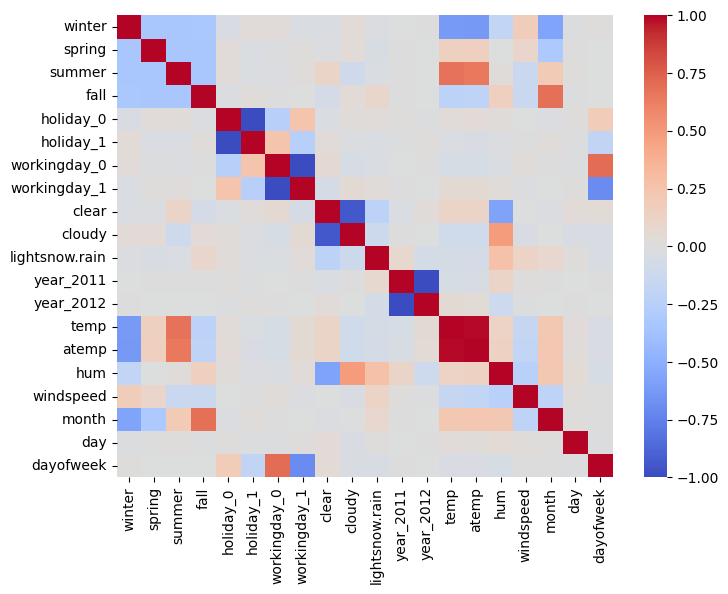

```python
plt.subplots(figsize=(8, 6))
sb.heatmap(Xdf.corr(), cmap='coolwarm')
```

```python
# Check if there is any non available
Xdf.isna().any().sum()
```

```
0
```

Define Y (to predict): Extract target

```python
# Here, indicate which target to predict (cnt or casual or registered)
# For the different models for each customer in the assignment, change the target
to_predict = 'cnt'
```

```python
# Here, indicate which target to predict (cnt or casual or registered)
y = df[to_predict]

# Normalize target data: Calculate mean and standard deviation
y_mu = y.mean(0)
y_sd = y.std(0)

print('y mean:', y_mu, ' y std:' , y_sd)

y_norm = (y - y_mu) / y_sd
y_norm = y_norm.values.ravel() #dataframe to 1D array
#y_norm
```

```
y mean: 4504.3488372093025  y std: 1937.2114516187676
```

```python
len(y)
```

```
731
```

```python
# to verify, leave a whole dataframe with x and y together
tdf = pd.concat([Xdf, pd.DataFrame(y.values)], axis = 1)
tdf.rename(columns={0:'cnt'}, inplace=True) #change the column name
tdf
```

|  | winter | spring | summer | fall | holiday_0 | holiday_1 | workingday_0 | workingday_1 | clear | cloudy | ... | year_2011 | year_2012 | temp | atemp | hum | windspeed | month | day | dayofweek | cnt |
| --- | --- | --- | --- | --- | --- | --- | --- | --- | --- | --- | --- | --- | --- | --- | --- | --- | --- | --- | --- | --- | --- |
| 0 | 1.0 | 0.0 | 0.0 | 0.0 | 1.0 | 0.0 | 1.0 | 0.0 | 0.0 | 1.0 | ... | 1.0 | 0.0 | -0.826662 | -0.679946 | 1.250171 | -0.387892 | -1.600161 | -1.674108 | 0.996930 | 985 |
| 1 | 1.0 | 0.0 | 0.0 | 0.0 | 1.0 | 0.0 | 1.0 | 0.0 | 0.0 | 1.0 | ... | 1.0 | 0.0 | -0.721095 | -0.740652 | 0.479113 | 0.749602 | -1.600161 | -1.560522 | 1.496077 | 801 |
| 2 | 1.0 | 0.0 | 0.0 | 0.0 | 1.0 | 0.0 | 0.0 | 1.0 | 1.0 | 0.0 | ... | 1.0 | 0.0 | -1.634657 | -1.749767 | -1.339274 | 0.746632 | -1.600161 | -1.446936 | -1.498809 | 1349 |
| 3 | 1.0 | 0.0 | 0.0 | 0.0 | 1.0 | 0.0 | 0.0 | 1.0 | 1.0 | 0.0 | ... | 1.0 | 0.0 | -1.614780 | -1.610270 | -0.263182 | -0.389829 | -1.600161 | -1.333351 | -0.999661 | 1562 |
| 4 | 1.0 | 0.0 | 0.0 | 0.0 | 1.0 | 0.0 | 0.0 | 1.0 | 1.0 | 0.0 | ... | 1.0 | 0.0 | -1.467414 | -1.504971 | -1.341494 | -0.046307 | -1.600161 | -1.219765 | -0.500513 | 1600 |
| ... | ... | ... | ... | ... | ... | ... | ... | ... | ... | ... | ... | ... | ... | ... | ... | ... | ... | ... | ... | ... | ... |
| 726 | 1.0 | 0.0 | 0.0 | 0.0 | 1.0 | 0.0 | 0.0 | 1.0 | 0.0 | 1.0 | ... | 0.0 | 1.0 | -1.318665 | -1.521108 | 0.175807 | 2.061426 | 1.588660 | 1.279122 | -0.001366 | 2114 |
| 727 | 1.0 | 0.0 | 0.0 | 0.0 | 1.0 | 0.0 | 0.0 | 1.0 | 0.0 | 1.0 | ... | 0.0 | 1.0 | -1.323224 | -1.346690 | -0.266238 | -0.452131 | 1.588660 | 1.392707 | 0.497782 | 3095 |
| 728 | 1.0 | 0.0 | 0.0 | 0.0 | 1.0 | 0.0 | 1.0 | 0.0 | 0.0 | 1.0 | ... | 0.0 | 1.0 | -1.323224 | -1.424344 | 0.878392 | -0.853552 | 1.588660 | 1.506293 | 0.996930 | 1341 |
| 729 | 1.0 | 0.0 | 0.0 | 0.0 | 1.0 | 0.0 | 1.0 | 0.0 | 1.0 | 0.0 | ... | 0.0 | 1.0 | -1.309558 | -1.490049 | -1.015664 | 2.069444 | 1.588660 | 1.619879 | 1.496077 | 1796 |
| 730 | 1.0 | 0.0 | 0.0 | 0.0 | 1.0 | 0.0 | 0.0 | 1.0 | 0.0 | 1.0 | ... | 0.0 | 1.0 | -1.528225 | -1.540482 | -0.354061 | -0.460201 | 1.588660 | 1.733465 | -1.498809 | 2729 |

731 rows × 21 columns

Split training and test data

```python
# Split the data into training, validation, and test data:
X_train, X_test, y_train, y_test = train_test_split(Xdf, y_norm, test_size = 0.2, random_state=1)
# Validation set
X_train, X_val, y_train, y_val = train_test_split(X_train, y_train, test_size=0.2, random_state=1)
```

# Grid search and modeling

```python
# A parameter grid for XGBoost
params = {
        'min_child_weight': [1, 5, 10],
        'gamma': [0.5, 1, 1.5, 2, 5],
        'subsample': [0.6, 0.8, 1.0],
        'colsample_bytree': [0.6, 0.8, 1.0],
        'max_depth': [3, 4, 5]
        }
```

```python
# Build the model with
# XGBoost Training Parameter Reference:
#   https://github.com/dmlc/xgboost
#   https://xgboost.readthedocs.io/en/latest/parameter.html

# XGBRegressor object and GridSearch object
xgbmodel = xgb.XGBRegressor()
clf = GridSearchCV(estimator = xgbmodel,
                   param_grid = params,
                   cv = 3,
                   verbose=1)
```

```python
# Fit the training data to the GridSearch object
t0 = time.time()
clf.fit(X_train, y_train)
t1 = time.time()
print(t1-t0, " sec taken")
```

```
Fitting 3 folds for each of 405 candidates, totalling 1215 fits
41.05784225463867  sec taken
```

```python
# Display the best parameters from the GridSearch
# Let's assume that this is a good enough model to use for SHAP
print(clf.best_params_)
print(clf.best_score_)
```

```
{'colsample_bytree': 0.8, 'gamma': 0.5, 'max_depth': 4, 'min_child_weight': 5, 'subsample': 0.8}
0.8633448414950647
```

# Train with best parameters

```python
from sklearn._config import get_config, set_config
set_config(print_changed_only=False)
```

```python
xgbmodel = xgb.XGBRegressor(**clf.best_params_, random_state=0)
```

```python
# Fit the training data to the model
xgbmodel.fit(X_train, y_train, eval_set = [(X_train, y_train), (X_val, y_val)])
```

```
XGBRegressor(base_score=0.5, booster='gbtree', callbacks=None,
             colsample_bylevel=1, colsample_bynode=1, colsample_bytree=0.8,
             early_stopping_rounds=None, enable_categorical=False,
             eval_metric=None, gamma=0.5, gpu_id=-1, grow_policy='depthwise',
             importance_type=None, interaction_constraints='',
             learning_rate=0.300000012, max_bin=256, max_cat_to_onehot=4,
             max_delta_step=0, max_depth=4, max_leaves=0, min_child_weight=5,
             missing=nan, monotone_constraints='()', n_estimators=100, n_jobs=0,
             num_parallel_tree=1, objective='reg:squarederror',
             predictor='auto', random_state=0, reg_alpha=0, ...)
```

# Predict

```python
eval_result = xgbmodel.evals_result()
training_rounds = range(len(eval_result['validation_0']['rmse'])) #training
print(training_rounds)
```

```
range(0, 100)
```

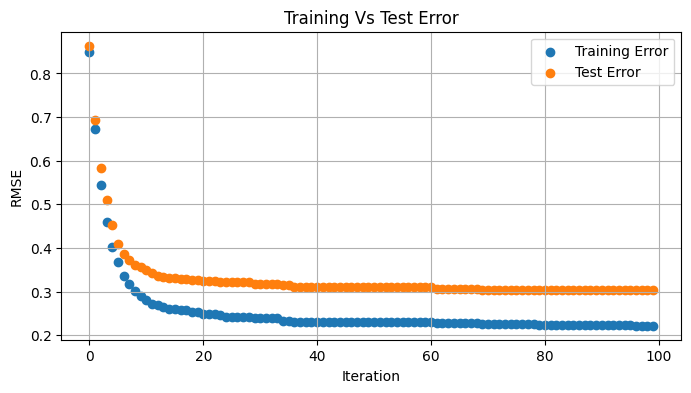

```python
plt.figure(figsize=(8,4))
plt.scatter(x=training_rounds,y=eval_result['validation_0']['rmse'],label='Training Error')
plt.scatter(x=training_rounds,y=eval_result['validation_1']['rmse'],label='Test Error')
plt.grid(True)
plt.xlabel('Iteration')
plt.ylabel('RMSE')
plt.title('Training Vs Test Error')
plt.legend()
plt.show()
```

```python
ypredicted = xgbmodel.predict(X_test)
```

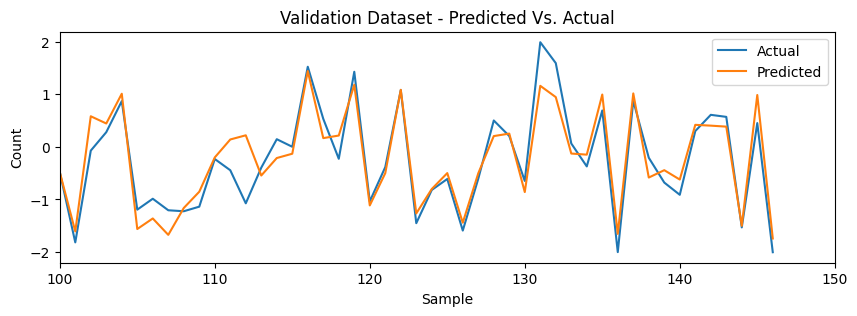

```python
plt.figure(figsize=(10,3))
# Actual Vs Predicted
plt.plot(y_test, label='Actual')
plt.plot(ypredicted, label='Predicted')
plt.xlabel('Sample')
plt.ylabel('Count')
plt.xlim([100,150])
plt.title('Validation Dataset - Predicted Vs. Actual')
plt.legend()
plt.show()
```

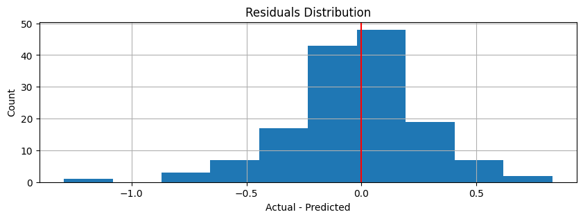

```python
# Over prediction and Under Prediction needs to be balanced
# Training Data Residuals
residuals = (y_test - ypredicted) # * y_sd + y_mu (for actual cnt numbers)

plt.figure(figsize=(10,3))
plt.hist(residuals)
plt.grid(True)
plt.xlabel('Actual - Predicted')
plt.ylabel('Count')
plt.title('Residuals Distribution')
plt.axvline(color='r')
plt.show()
```

```python
print("RMSE: {0:0.4f}".format(mean_squared_error(y_test, ypredicted)))
```

```
RMSE: 0.0884
```

```python
# Show the influencing features in order (with feature_importances_)
# Indicate which parameter used to decide the ranking of important features
important_features = pd.Series(data=xgbmodel.feature_importances_, index=NAMES)
important_features.sort_values(ascending=False,inplace=True)
print(important_features)

# There are different parameters:
# Refer to, https://github.com/dmlc/xgboost/blob/master/python-package/xgboost/core.py
#        * 'weight': the number of times a feature is used to split the data across all trees.
#        * 'gain': the average gain across all splits the feature is used in.
#        * 'cover': the average coverage across all splits the feature is used in.
#        * 'total_gain': the total gain across all splits the feature is used in.
#        * 'total_cover': the total coverage across all splits the feature is used in.
```

```
year_2012         0.334441
month             0.148238
year_2011         0.093973
atemp             0.091646
winter            0.060549
fall              0.057606
clear             0.034687
cloudy            0.033488
temp              0.031691
lightsnow.rain    0.028922
hum               0.022926
windspeed         0.017095
workingday_0      0.010901
holiday_0         0.009047
day               0.007691
dayofweek         0.007369
workingday_1      0.007166
spring            0.002563
holiday_1         0.000000
summer            0.000000
dtype: float32
```

```python
important_features = pd.Series(data=xgbmodel.get_booster().get_score(importance_type='gain'), index=NAMES)
important_features.sort_values(ascending=False,inplace=True)
print(important_features)
```

```
year_2012         24.965618
month             11.065815
year_2011          7.015012
atemp              6.841238
winter             4.519948
fall               4.300218
clear              2.589336
cloudy             2.499860
temp               2.365730
lightsnow.rain     2.159016
hum                1.711424
windspeed          1.276122
workingday_0       0.813746
holiday_0          0.675331
day                0.574106
dayofweek          0.550102
workingday_1       0.534939
spring             0.191319
summer                  NaN
holiday_1               NaN
dtype: float64
```

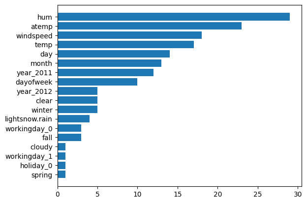

```python
# Show the influencing features in order (with get_booster().get_fscore())
# fscore is based on the number of times a feature is used in a tree
fscore = xgbmodel.get_booster().get_fscore().items()
lists = sorted(fscore, key=lambda x:x[1]) # sorted by value, return a list of tuples
fkey, fvalue = zip(*lists) # unpack a list of pairs into two tuples

plt.barh(fkey, fvalue)
plt.show()
```

# Check which single instances to compare with LIME

To find a single day to examine, search for conditions and pick a specific index to investigate

```python
# weekend and winter
sampled_at_hu = X_test[(X_test['workingday_0']==1) & (X_test['winter']==1)][:5]
sampled_at_hu
```

|  | winter | spring | summer | fall | holiday_0 | holiday_1 | workingday_0 | workingday_1 | clear | cloudy | lightsnow.rain | year_2011 | year_2012 | temp | atemp | hum | windspeed | month | day | dayofweek |
| --- | --- | --- | --- | --- | --- | --- | --- | --- | --- | --- | --- | --- | --- | --- | --- | --- | --- | --- | --- | --- |
| 8 | 1.0 | 0.0 | 0.0 | 0.0 | 1.0 | 0.0 | 1.0 | 0.0 | 1.0 | 0.0 | 0.0 | 1.0 | 0.0 | -1.951895 | -2.199446 | -1.361096 | 2.214012 | -1.600161 | -0.765422 | 1.496077 |
| 364 | 1.0 | 0.0 | 0.0 | 0.0 | 1.0 | 0.0 | 1.0 | 0.0 | 1.0 | 0.0 | 0.0 | 1.0 | 0.0 | -0.466773 | -0.369869 | -0.084739 | 0.383083 | 1.588660 | 1.733465 | 0.996930 |
| 414 | 1.0 | 0.0 | 0.0 | 0.0 | 1.0 | 0.0 | 1.0 | 0.0 | 0.0 | 1.0 | 0.0 | 0.0 | 1.0 | -1.177444 | -1.280727 | -0.787324 | 0.808650 | -1.310268 | 0.370436 | 1.496077 |
| 434 | 1.0 | 0.0 | 0.0 | 0.0 | 1.0 | 0.0 | 1.0 | 0.0 | 1.0 | 0.0 | 0.0 | 0.0 | 1.0 | -1.136444 | -1.207168 | -1.949511 | 0.455341 | -1.020375 | -0.651836 | 0.996930 |
| 421 | 1.0 | 0.0 | 0.0 | 0.0 | 1.0 | 0.0 | 1.0 | 0.0 | 1.0 | 0.0 | 0.0 | 0.0 | 1.0 | -1.181998 | -1.265253 | -1.530890 | 0.190365 | -1.310268 | 1.165536 | 1.496077 |

```python
PICK = 364
Xdf[Xdf.index==PICK]
```

|  | winter | spring | summer | fall | holiday_0 | holiday_1 | workingday_0 | workingday_1 | clear | cloudy | lightsnow.rain | year_2011 | year_2012 | temp | atemp | hum | windspeed | month | day | dayofweek |
| --- | --- | --- | --- | --- | --- | --- | --- | --- | --- | --- | --- | --- | --- | --- | --- | --- | --- | --- | --- | --- |
| 364 | 1.0 | 0.0 | 0.0 | 0.0 | 1.0 | 0.0 | 1.0 | 0.0 | 1.0 | 0.0 | 0.0 | 1.0 | 0.0 | -0.466773 | -0.369869 | -0.084739 | 0.383083 | 1.58866 | 1.733465 | 0.99693 |

```python
# review the target values, y[364] and tdf[tdf.index == 364]['cnt'].values[0] show target cnt = 2485
print(tdf[tdf.index == PICK]['cnt'].values[0])
```

```
2485
```

```python
Xdf.iloc[[PICK]]
```

|  | winter | spring | summer | fall | holiday_0 | holiday_1 | workingday_0 | workingday_1 | clear | cloudy | lightsnow.rain | year_2011 | year_2012 | temp | atemp | hum | windspeed | month | day | dayofweek |
| --- | --- | --- | --- | --- | --- | --- | --- | --- | --- | --- | --- | --- | --- | --- | --- | --- | --- | --- | --- | --- |
| 364 | 1.0 | 0.0 | 0.0 | 0.0 | 1.0 | 0.0 | 1.0 | 0.0 | 1.0 | 0.0 | 0.0 | 1.0 | 0.0 | -0.466773 | -0.369869 | -0.084739 | 0.383083 | 1.58866 | 1.733465 | 0.99693 |

Keep one day for local explanation later.

Find the appropriate single day to explain. Here, we focus on days in indices 364 and 180.

```python
# Select one day for investigation with a force plot later
weekEnd_sample = Xdf.loc[[364]] #weekend-winter-364      #working day-winter-40
weekDay_sample = Xdf.loc[[180]] #working day-summer-180  #weekend-summer-247

weekEnd_sample_origin = X_original.loc[[364]]
weekDay_sample_origin = X_original.loc[[180]]
weekEnd_sample_origin #weekDay_sample_origin
```

|  | winter | spring | summer | fall | holiday_0 | holiday_1 | workingday_0 | workingday_1 | clear | cloudy | lightsnow.rain | year_2011 | year_2012 | temp | atemp | hum | windspeed | month | day | dayofweek |
| --- | --- | --- | --- | --- | --- | --- | --- | --- | --- | --- | --- | --- | --- | --- | --- | --- | --- | --- | --- | --- |
| 364 | 1.0 | 0.0 | 0.0 | 0.0 | 1.0 | 0.0 | 1.0 | 0.0 | 1.0 | 0.0 | 0.0 | 1.0 | 0.0 | 16.81 | 20.70605 | 61.5833 | 14.750318 | 12.0 | 31.0 | 5.0 |

# Explain model with SHAP

```python
X_original.head(5)
```

|  | winter | spring | summer | fall | holiday_0 | holiday_1 | workingday_0 | workingday_1 | clear | cloudy | lightsnow.rain | year_2011 | year_2012 | temp | atemp | hum | windspeed | month | day | dayofweek |
| --- | --- | --- | --- | --- | --- | --- | --- | --- | --- | --- | --- | --- | --- | --- | --- | --- | --- | --- | --- | --- |
| 0 | 1.0 | 0.0 | 0.0 | 0.0 | 1.0 | 0.0 | 1.0 | 0.0 | 0.0 | 1.0 | 0.0 | 1.0 | 0.0 | 14.110847 | 18.18125 | 80.5833 | 10.749882 | 1.0 | 1.0 | 5.0 |
| 1 | 1.0 | 0.0 | 0.0 | 0.0 | 1.0 | 0.0 | 1.0 | 0.0 | 0.0 | 1.0 | 0.0 | 1.0 | 0.0 | 14.902598 | 17.68695 | 69.6087 | 16.652113 | 1.0 | 2.0 | 6.0 |
| 2 | 1.0 | 0.0 | 0.0 | 0.0 | 1.0 | 0.0 | 0.0 | 1.0 | 1.0 | 0.0 | 0.0 | 1.0 | 0.0 | 8.050924 | 9.47025 | 43.7273 | 16.636703 | 1.0 | 3.0 | 0.0 |
| 3 | 1.0 | 0.0 | 0.0 | 0.0 | 1.0 | 0.0 | 0.0 | 1.0 | 1.0 | 0.0 | 0.0 | 1.0 | 0.0 | 8.200000 | 10.60610 | 59.0435 | 10.739832 | 1.0 | 4.0 | 1.0 |
| 4 | 1.0 | 0.0 | 0.0 | 0.0 | 1.0 | 0.0 | 0.0 | 1.0 | 1.0 | 0.0 | 0.0 | 1.0 | 0.0 | 9.305237 | 11.46350 | 43.6957 | 12.522300 | 1.0 | 5.0 | 2.0 |

```python
# activate javascript, load javascript library when visualization is not showing
shap.initjs()

# explain all the predictions in the test set
t0 = time.time()
explainer = shap.TreeExplainer(xgbmodel)
shap_values = explainer.shap_values(Xdf)
t1 = time.time()
print(t1-t0, " sec taken")
```

```
0.031958580017089844  sec taken
```

```
ntree_limit is deprecated, use `iteration_range` or model slicing instead.
```

- Note: xgbmodel contains training data set that it was built upon.
- TreeExplainer uses this model to compute conditional expectations.
- Pass to explainer.shap_values the data samples to explain: it is often a test set, but in this case we use the full set.

# Global explanation (overall)

# SHAP Summary Plot

The SHAP values for XGBoost explain the margin output of the model, which explains the bike rental model.

This summary plot shows which features are most significant, and their range of effects over the dataset. It also reveals the positive and negative relationships of the predictors with the target variable in descending order. The top variables contribute more to the model than the bottom and thus exhibit high predictive power. The color shows how changes in the value of a feature affect the change of the target, which here are the counts of renting a bike.

- y-axis: Variable name, in the order of importance from top to bottom.
- x-axis: SHAP value, indicates the impact of each feature on renting a bike (above zero shows positive, otherwise negative). It shows whether the effect of that value is associated with a higher or lower prediction.
- Gradient color: Value for the variable. In boolean, it will take two colors (e.g., year), but in numbers, it can contain the whole colormap spectrum.
- Each point: a row from the original dataset.

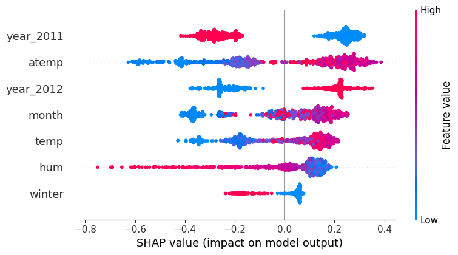

```python
#shap.summary_plot(shap_values) OR shap.plots.beeswarm(shap_values)
shap.summary_plot(shap_values, Xdf, feature_names=NAMES, max_display=7) #plot_type="bar" for bar type
```

- People rented fewer bikes in 2011 but opposite in 2012.
  - Year 2011 is negatively correlated with the target variable, with lesser customers renting a bike.
- People rented more bikes if feeling temperature and temperature are higher.
  - Temperature is positively correlated with the target variable, with more customers renting a bike.

# SHAP Dependence Plot

While a SHAP summary plot provides a general overview of each feature, a SHAP dependence plot shows how the model output varies by feauture value. Note that every dot is a datapoint (e.g., each day), and the vertical dispersion at a single feature value results from interaction effects in the model.

If interaction_index=None, the dependence plot only shows a single feature. Otherwise, the feature used for coloring is automatically chosen to highlight what might be driving these interactions. Later we will see how to check that the interaction is really in the model with SHAP interaction values. Note that the row of a SHAP summary plot results from projecting the points of a SHAP dependence plot onto the y-axis, then recoloring by the feature itself.

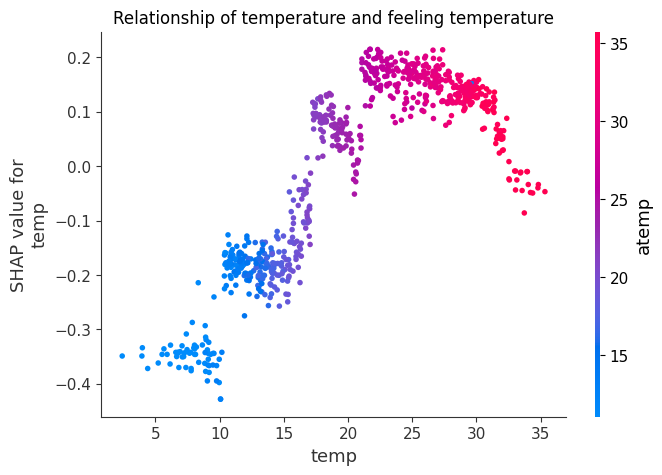

```python
# Use the dependence plot
# The shap_values[0] are explanations with respect to the negative class, while shap_values[1] are explanations with respect to the positive class
# X_original to view the original numerical data
# Can turn off interaction coloring with "interaction_index=None"
shap.dependence_plot("temp", shap_values, X_original, feature_names=NAMES, show=False) # interaction_index=None
plt.title("Relationship of temperature and feeling temperature");
```

- Lower temperature shows a big decrease in shap values indicating lower rental counts.
- At a certain point, the rental decreases when temperature grows.

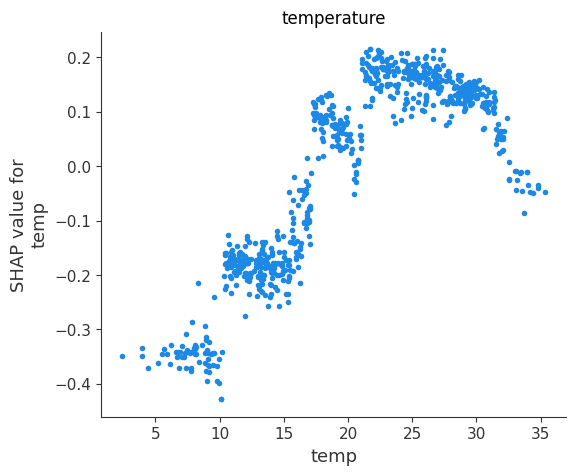

```python
shap.dependence_plot("temp", shap_values, X_original, feature_names=NAMES, show=False, interaction_index = None) # interaction_index=None
plt.title("temperature");
```

# SHAP Interaction Value Plot

SHAP interaction value matrix plots a matrix of summary plots with the main effects on the diagonal and the interaction effects off the diagonal.

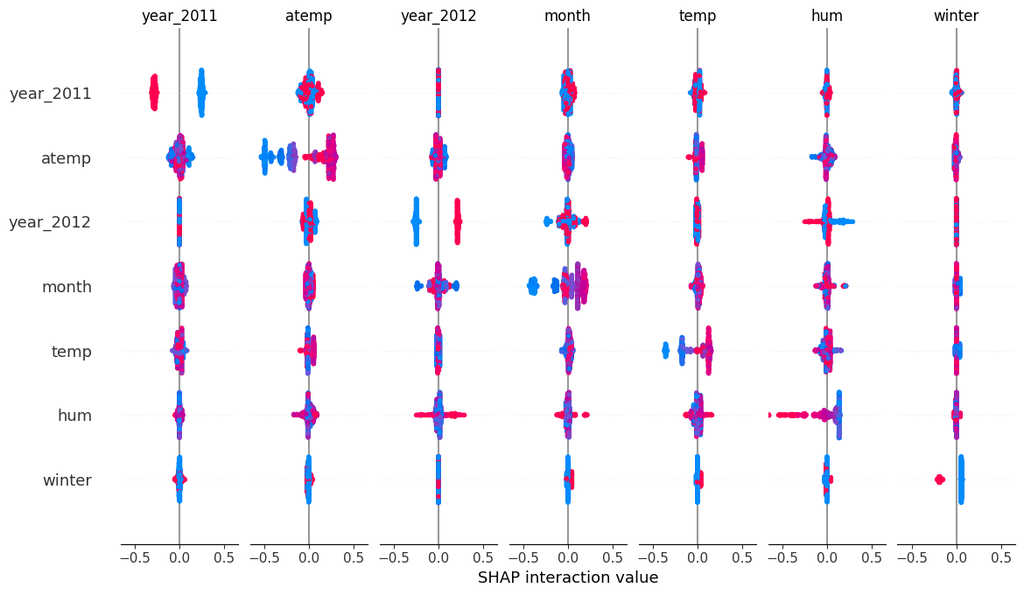

```python
shap_interaction_values = explainer.shap_interaction_values(Xdf)
shap.summary_plot(shap_interaction_values, Xdf, feature_names=NAMES)
```

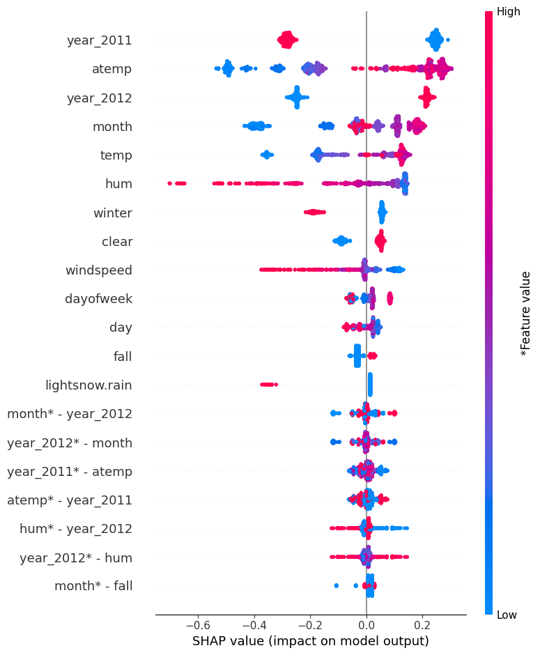

```python
# Show interactions together
# Generate a summary plot with ranking both the individual features and interactions with plot type "compact dot".
shap.summary_plot(shap_interaction_values, Xdf, feature_names=NAMES, plot_type="compact_dot")
```

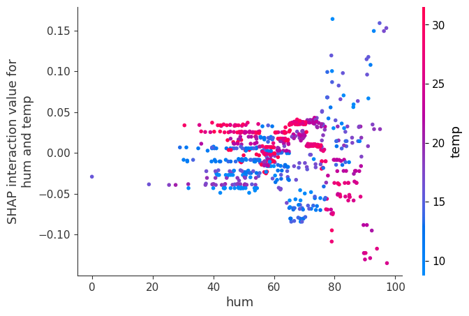

```python
# Select two variables to show interactions
# X_original to view the original numerical data
shap.dependence_plot(
    ("hum","temp"),
    shap_interaction_values, X_original)
```

A rise in temperature and humidity reduces the likelihood of renting a bicycle. But, the predicted rental probability increases although humidity is higher when temperature is lower.

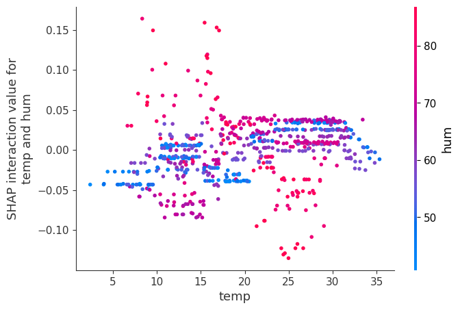

```python
# Select one variable
# X_original to view the original numerical data
shap.dependence_plot(
    ("temp", "hum"), #"atemp", "temp"   / "temp", "atemp"
    shap_interaction_values, X_original)
```

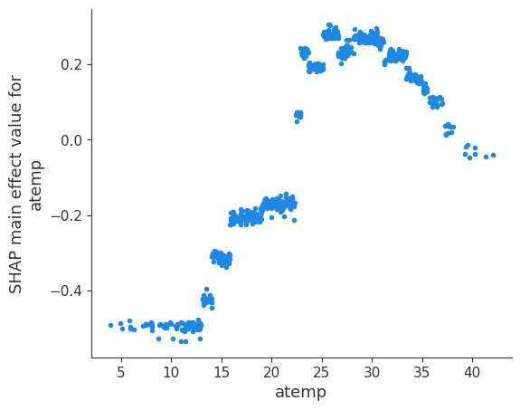

```python
# Select one variable
# X_original to view the original numerical data
shap.dependence_plot(
    ("atemp", "atemp"),
    shap_interaction_values, X_original)
```

- Explain the model: Describe the relationship of humidity and temperature towards the bike rental prediction.

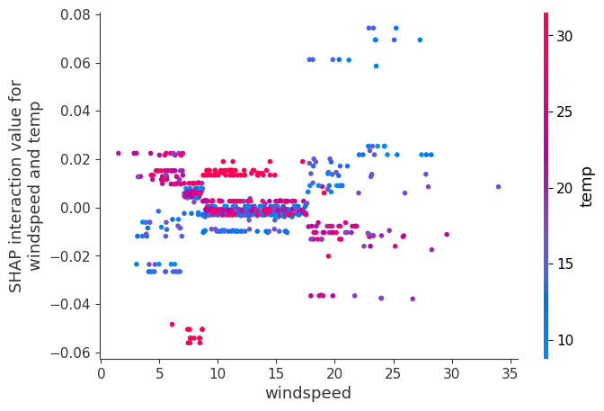

```python
shap.dependence_plot(
    ("windspeed", "temp"),
    shap_interaction_values, X_original)
```

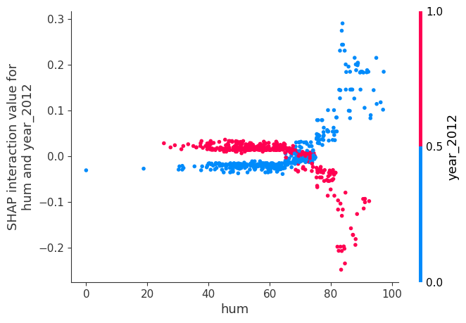

```python
# erase this in tutorial to students (in the assignment actually)
shap.dependence_plot(
    ("hum", "year_2012"),
    shap_interaction_values, X_original)
```

- Explain the model: Describe the relationship of wind speed and temperature towards the bike rental prediction.

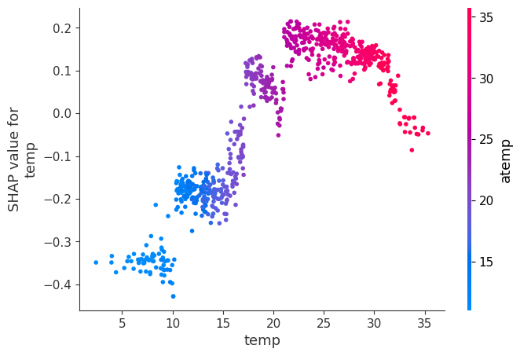

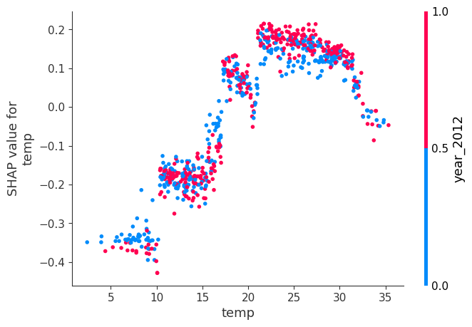

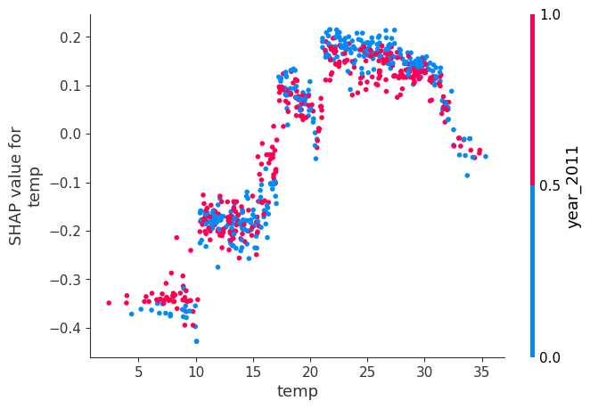

```python
# select a feature and see the top related features
SELECTED = "temp"
# we can use shap.approximate_interactions to view which features interact
inds = shap.approximate_interactions(SELECTED, shap_values, Xdf, feature_names=NAMES)

# make plots colored by each of the top three possible interacting features
for i in range(3):
    shap.dependence_plot(SELECTED, shap_values, X_original, interaction_index=inds[i], feature_names=NAMES)
```

- Explain the model: Find the difference between 2011 and 2012 with temperature? Describe the relationship of temperature and other features' interactions.

## Quantify interactions (using the average of shap interaction values)

```python
intrct_avg = np.abs(shap_interaction_values).mean(0)
intrct_avg_nodiag = intrct_avg.copy()
np.fill_diagonal(intrct_avg_nodiag, 0)
intrct_df = pd.DataFrame(intrct_avg_nodiag)
intrct_df.columns = NAMES
intrct_df.index = NAMES
print(intrct_df) # find a way to order by value for each variable
```

```
                  winter    spring  summer      fall  holiday_0  holiday_1  \
winter          0.000000  0.000000     0.0  0.000000   0.000000        0.0
spring          0.000000  0.000000     0.0  0.000000   0.000000        0.0
summer          0.000000  0.000000     0.0  0.000000   0.000000        0.0
fall            0.000000  0.000000     0.0  0.000000   0.000000        0.0
holiday_0       0.000000  0.000000     0.0  0.000000   0.000000        0.0
holiday_1       0.000000  0.000000     0.0  0.000000   0.000000        0.0
workingday_0    0.000000  0.000000     0.0  0.000000   0.000000        0.0
workingday_1    0.000000  0.000000     0.0  0.000000   0.000000        0.0
clear           0.004483  0.000000     0.0  0.000000   0.000000        0.0
cloudy          0.000000  0.000000     0.0  0.000000   0.000000        0.0
lightsnow.rain  0.001094  0.000000     0.0  0.000000   0.000000        0.0
year_2011       0.004630  0.000000     0.0  0.003178   0.000000        0.0
year_2012       0.000000  0.000000     0.0  0.008275   0.000000        0.0
temp            0.003069  0.000000     0.0  0.001622   0.001352        0.0
atemp           0.003847  0.002271     0.0  0.000000   0.000000        0.0
hum             0.002219  0.000000     0.0  0.000000   0.000371        0.0
windspeed       0.007345  0.000000     0.0  0.000000   0.000000        0.0
month           0.003097  0.000000     0.0  0.015353   0.000000        0.0
day             0.002092  0.000262     0.0  0.001183   0.000000        0.0
dayofweek       0.002304  0.000000     0.0  0.000000   0.000000        0.0

                workingday_0  workingday_1     clear    cloudy  \
winter              0.000000      0.000000  0.004483  0.000000
spring              0.000000      0.000000  0.000000  0.000000
summer              0.000000      0.000000  0.000000  0.000000
fall                0.000000      0.000000  0.000000  0.000000
holiday_0           0.000000      0.000000  0.000000  0.000000
holiday_1           0.000000      0.000000  0.000000  0.000000
workingday_0        0.000000      0.000000  0.000000  0.000000
workingday_1        0.000000      0.000000  0.000000  0.000000
clear               0.000000      0.000000  0.000000  0.007569
cloudy              0.000000      0.000000  0.007569  0.000000
lightsnow.rain      0.000000      0.000128  0.000000  0.000000
year_2011           0.000000      0.000000  0.008718  0.004726
year_2012           0.002857      0.000000  0.003621  0.000000
temp                0.002810      0.000000  0.000000  0.000000
atemp               0.000000      0.003399  0.011830  0.003959
hum                 0.000000      0.001687  0.000000  0.000000
windspeed           0.003309      0.000000  0.006440  0.000000
```

[output cut: 32 more lines]

```
holiday_1       0.000000   0.000000  0.000000  0.000000   0.000000
workingday_0    0.000000   0.003309  0.005686  0.000000   0.000000
workingday_1    0.001687   0.000000  0.000000  0.000000   0.000000
clear           0.000000   0.006440  0.003403  0.003684   0.002692
cloudy          0.000000   0.000000  0.000000  0.000000   0.000000
lightsnow.rain  0.001300   0.000718  0.000000  0.000185   0.000000
year_2011       0.004177   0.006936  0.010104  0.003803   0.005359
year_2012       0.017533   0.001921  0.021782  0.003146   0.002819
temp            0.014357   0.004561  0.009057  0.005203   0.004640
atemp           0.012719   0.008482  0.008980  0.003303   0.004683
hum             0.000000   0.006630  0.008477  0.006912   0.003069
windspeed       0.006630   0.000000  0.003606  0.000000   0.000000
month           0.008477   0.003606  0.000000  0.009718   0.005111
day             0.006912   0.000000  0.009718  0.000000   0.001585
dayofweek       0.003069   0.000000  0.005111  0.001585   0.000000
```

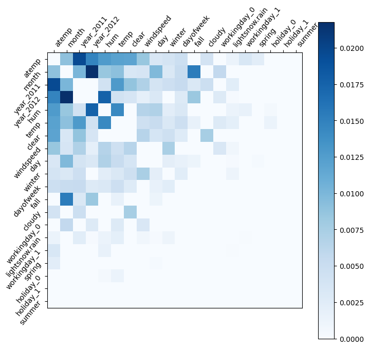

```python
tmp = np.abs(shap_interaction_values).mean(0)
for i in range(tmp.shape[0]):
    tmp[i,i] = 0
inds = np.argsort(-tmp.sum(0))[:50]
tmp2 = tmp[inds,:][:,inds]
plt.figure(figsize=(8,8))
plt.imshow(tmp2, cmap=plt.get_cmap("Blues"))
plt.colorbar()
plt.yticks(range(tmp2.shape[0]), Xdf.columns.values[inds], rotation=50.4, horizontalalignment="right")
plt.xticks(range(tmp2.shape[0]), Xdf.columns.values[inds], rotation=50.4, horizontalalignment="left")
plt.gca().xaxis.tick_top()
plt.show()
```

# Local explanation (one day)

# Find the shap values for one day: Weekend, Winter

```python
# Input changes to one day for local explanation
shap_wkend_values = explainer.shap_values(weekEnd_sample)
```

```
ntree_limit is deprecated, use `iteration_range` or model slicing instead.
```

```python
weekEnd_sample_origin
```

|  | winter | spring | summer | fall | holiday_0 | holiday_1 | workingday_0 | workingday_1 | clear | cloudy | lightsnow.rain | year_2011 | year_2012 | temp | atemp | hum | windspeed | month | day | dayofweek |
| --- | --- | --- | --- | --- | --- | --- | --- | --- | --- | --- | --- | --- | --- | --- | --- | --- | --- | --- | --- | --- |
| 364 | 1.0 | 0.0 | 0.0 | 0.0 | 1.0 | 0.0 | 1.0 | 0.0 | 1.0 | 0.0 | 0.0 | 1.0 | 0.0 | 16.81 | 20.70605 | 61.5833 | 14.750318 | 12.0 | 31.0 | 5.0 |

# SHAP Force Plot (for single instance, one day, local)

```python
#activate javascript
shap.initjs()
# Use force plot
# "_origin" to view the original numerical data
shap.force_plot(explainer.expected_value, shap_wkend_values, weekEnd_sample_origin, feature_names=NAMES)
```